# DATA612 Project 2

John K. Hancock

6/11/2020

# 1 Project Scope

The goal of this assignment is for you to try out different ways of implementing and configuring a recommender, and to evaluate your different approaches.

# 2 Introduction

This project builds two recommender systems: User Based Collaborative Filtering (UBCF) and Item Based Collaborative Filtering (ICBF) using data from the MovieLense database.

The project closely follows the tutorial in chapters 3 and 4 of the text, Building A Recommendation System with R by Suresh K. Gorka and Michele Usuelli.

# 3 Import Data

I began by downing the the MovieLense rating matrix which is within the Recommenderlab R package [Link](https://cran.r-project.org/web/packages/recommenderlab/vignettes/recommenderlab.pdf)

```r
data("MovieLense")
MovieLense
```

```
## 943 x 1664 rating matrix of class 'realRatingMatrix' with 99392 ratings.
```

# 4 Data Exploration

## 4.1 Similarity of Users and Items

```r
ratings_movies <- MovieLense[rowCounts(MovieLense) > 100, colCounts(MovieLense) > 200]
ratings_movies
```

```
## 358 x 116 rating matrix of class 'realRatingMatrix' with 22112 ratings.
```

In the code block below, I computed the similarity between the first four users and items in the ratings_movies object using the Pearson similarity method.

```r
similarity_users <- similarity(ratings_movies[1:4, ], method ="pearson", which = "users")
as.matrix(similarity_users)
```

```
##           1         5         6         7
## 1 0.0000000 0.5878441 0.5833309 0.5243777
## 5 0.5878441 0.0000000 0.5234117 0.5091642
## 6 0.5833309 0.5234117 0.0000000 0.6123778
## 7 0.5243777 0.5091642 0.6123778 0.0000000
```

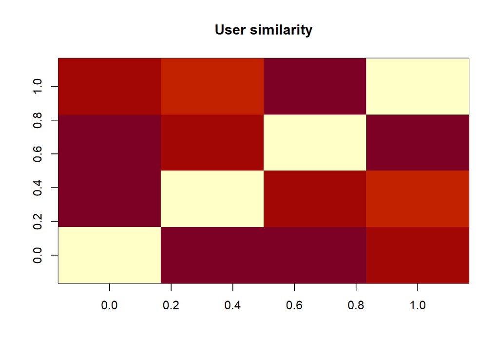

```r
image(as.matrix(similarity_users), main = "User similarity")
```

```r
similarity_items <- similarity(ratings_movies[, 1:4], method ="pearson", which = "items")
as.matrix(similarity_items)
```

```
##                       Toy Story (1995) Get Shorty (1995) Twelve Monkeys (1995)
## Toy Story (1995)             0.0000000         0.5234734             0.5653624
## Get Shorty (1995)            0.5234734         0.0000000             0.5377089
## Twelve Monkeys (1995)        0.5653624         0.5377089             0.0000000
## Babe (1995)                  0.5531670         0.6005361             0.5566206
##                       Babe (1995)
## Toy Story (1995)        0.5531670
## Get Shorty (1995)       0.6005361
## Twelve Monkeys (1995)   0.5566206
## Babe (1995)             0.0000000
```

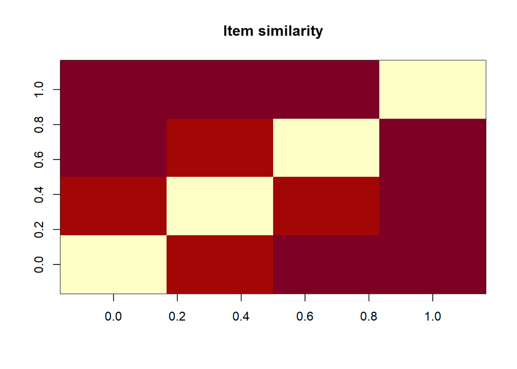

```r
image(as.matrix(similarity_items), main = "Item similarity")
```

## 4.2 Exploration of Ratings

The visualization below shows the frequency distribution of ratings after removing those movies without ratings. We see that the rating of “4” is the most often used rating on a scale of 1 to 5.

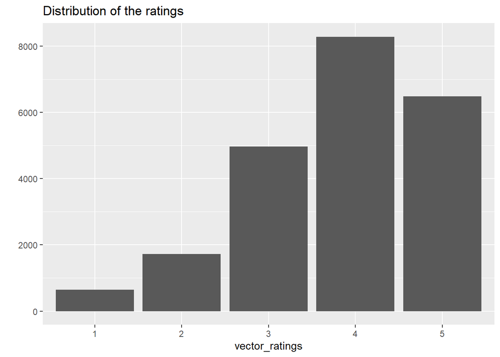

```r
vector_ratings <- as.vector(ratings_movies@data)
vector_ratings <- factor(vector_ratings[vector_ratings !=0])
vector_ratings_df <- as.data.frame(vector_ratings)

qplot(vector_ratings) + ggtitle("Distribution of the ratings")
```

```r
views_per_movie <- colCounts(ratings_movies)
views_per_movie_df <- as.data.frame(views_per_movie)
views_per_movie_df <- cbind(movies = rownames(views_per_movie_df), views_per_movie_df)
rownames(views_per_movie_df) <- 1:nrow(views_per_movie_df)

views_per_movie_df  <- views_per_movie_df[order(views_per_movie_df$views_per_movie, decreasing = TRUE), ]

head(views_per_movie_df,5)
```

```
##                            movies views_per_movie
## 12               Star Wars (1977)             325
## 43 Raiders of the Lost Ark (1981)             304
## 48      Return of the Jedi (1983)             298
## 61      Back to the Future (1985)             276
## 26                   Fargo (1996)             271
```

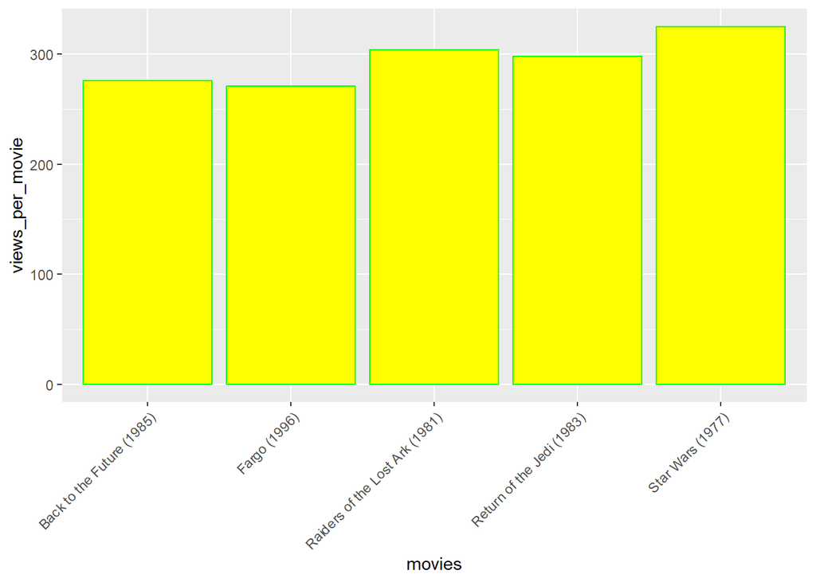

```r
ggplot(views_per_movie_df[1:5, ], aes(x=movies, y=views_per_movie)) +
  geom_bar(stat="identity",colour="green", fill="yellow") + theme(axis.text.x =element_text(angle = 45, hjust = 1))
```

## 4.3 Visualization of the top 5 percent of users and movies

```r
min_movies <- quantile(rowCounts(ratings_movies), 0.95)
min_users <- quantile(colCounts(ratings_movies), 0.95)
```

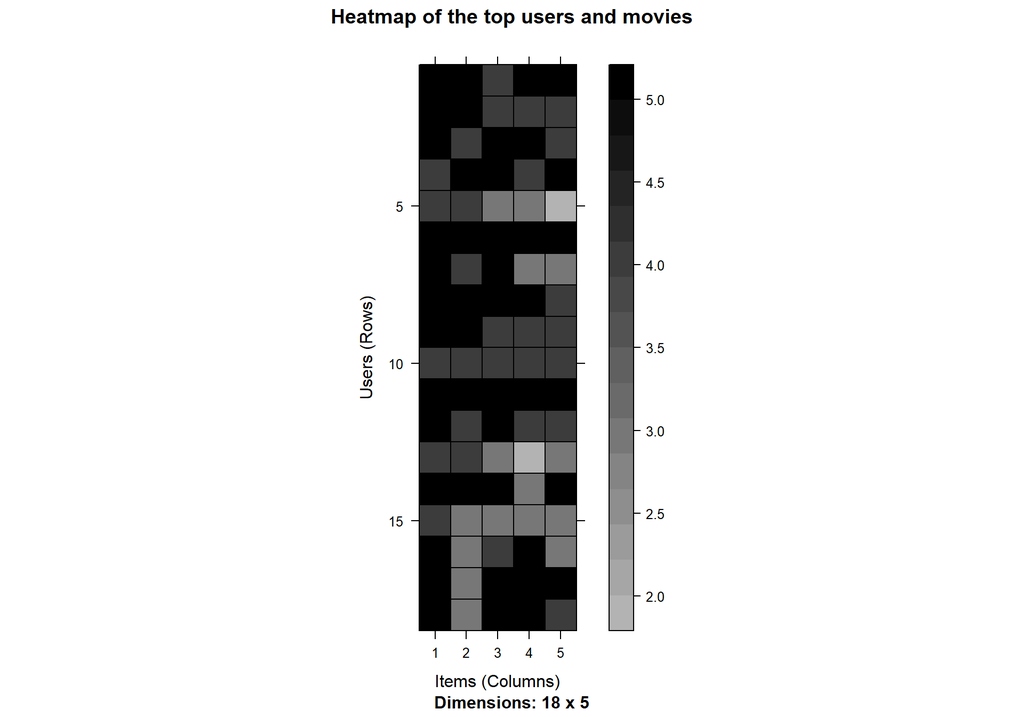

```r
image(ratings_movies[rowCounts(ratings_movies) > min_movies,
colCounts(ratings_movies) > min_users], main = "Heatmap of the top users and movies")
```

## 4.4 Average Ratings per User

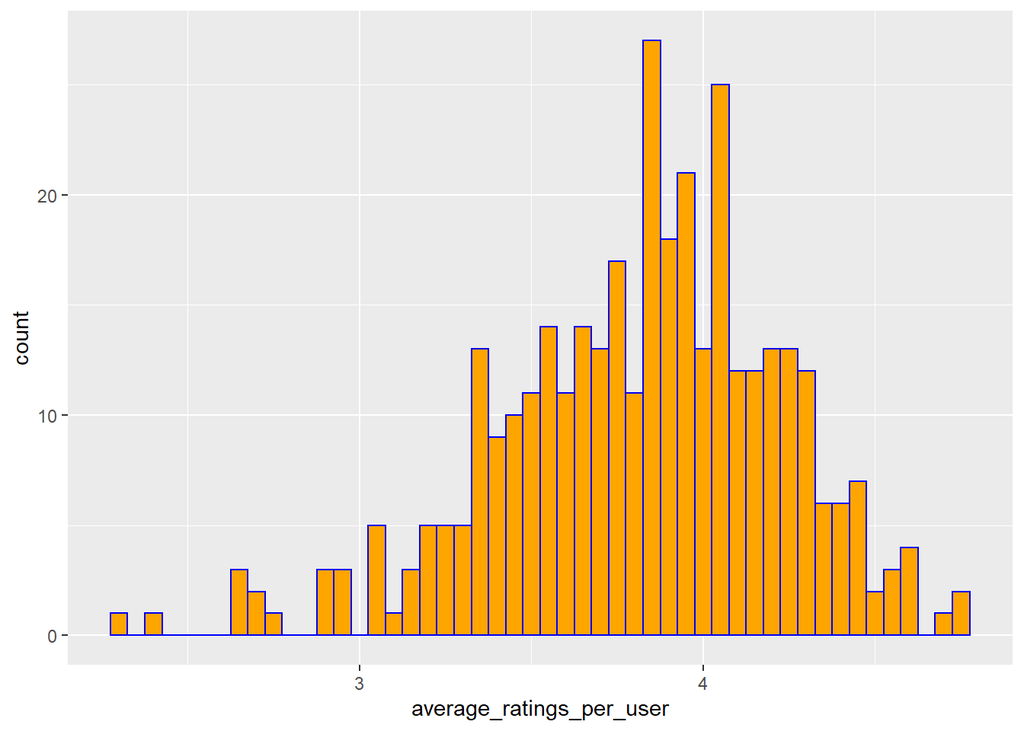

```r
average_ratings_per_user <- rowMeans(ratings_movies)

p1 <- ggplot() + aes(average_ratings_per_user)+ geom_histogram(binwidth=.05, colour="blue", fill="orange")
p1
```

## Average Movie Ratings

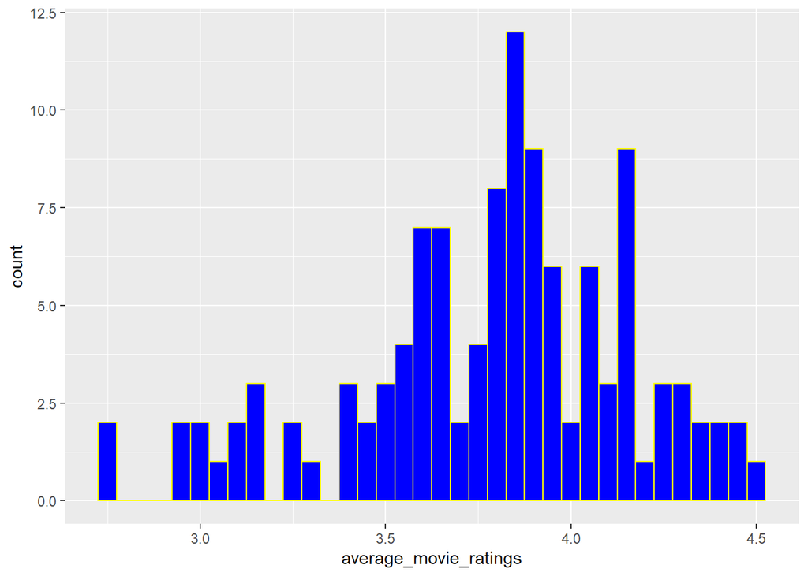

```r
average_movie_ratings<- colMeans(ratings_movies)

p2 <- ggplot() + aes(average_movie_ratings)+ geom_histogram(binwidth=.05, colour="yellow", fill="blue")
p2
```

# 5 Splitting the Data

I used two different methods for splitting the data. First, I manually created a test and train sets from ratings_movies. Next, I used K-Fold splitting to create 8 different chunks of data where a chunk is taken out, tested, and validated. The same is done with the other chunks and the average accuracy is taken.

## 5.1 Manually Split the Data

```r
set.seed(123)
which_train <- sample(x = c(TRUE, FALSE), size = nrow(ratings_movies), replace = TRUE, prob = c(0.8, 0.2))
recc_data_train <- ratings_movies[which_train, ]
recc_data_test <- ratings_movies[!which_train, ]
```

## 5.2 K-Fold Split

```r
n_fold <- 8
items_to_keep <- 10
rating_threshold <- 3
```

```r
k_fold_split <- function(data, method, n_fold, items_to_keep, rating_threshold){

        return(evaluationScheme(data = data, method = method, k = n_fold, given = items_to_keep, goodRating = rating_threshold))

  }
```

```r
eval_sets <- k_fold_split(ratings_movies, "cross-validation", n_fold, items_to_keep, rating_threshold)
```

```r
size_sets <- sapply(eval_sets@runsTrain, length)
size_sets
```

```
## [1] 308 308 308 308 308 308 308 308
```

# 6 Build Models - User Based Collaborative Filtering (UBCF)

## 6.1 Method One - Using the manual Split

UBCF model was built on the train set, recc_data_train.

```r
UBCF_recc_model <- Recommender(data = recc_data_train, method = "UBCF")
UBCF_recc_model
```

```
## Recommender of type 'UBCF' for 'realRatingMatrix'
## learned using 291 users.
```

The model recommends 5 movies to each user.

```r
n_recommended <- 5
recc_predicted <- predict(object = UBCF_recc_model, newdata = recc_data_test, n = n_recommended)
UBCF_recc_matrix <- sapply(recc_predicted@items, function(x){
                                                          colnames(ratings_movies)[x] })
```

We can see the slots for the recc_predicted model as well as the predicted user ratings for each film.

```r
slotNames(recc_predicted)
```

```
## [1] "items"      "ratings"    "itemLabels" "n"
```

```r
recc_predicted@ratings[1:5]
```

```
## $`7`
## [1] 4.534113 4.459819 4.394825 4.370785 4.254145
##
## $`10`
## [1] 4.721341 4.633436 4.629731 4.610652 4.602927
##
## $`15`
## [1] 3.389964 3.358901 3.347940 3.278984 3.276877
##
## $`21`
## [1] 4.062008 3.929971 3.891427 3.821683 3.814816
##
## $`42`
## [1] 4.463283 4.403875 4.367245 4.363597 4.359057
```

In the table below, we see the names of the five recommmended movies for the top 5 users.

| 7 | 10 | 15 | 21 | 42 |
| --- | --- | --- | --- | --- |
| Titanic (1997) | Princess Bride, The (1987) | Silence of the Lambs, The (1991) | Usual Suspects, The (1995) | Braveheart (1995) |
| Trainspotting (1996) | Boot, Das (1981) | Empire Strikes Back, The (1980) | Shawshank Redemption, The (1994) | Titanic (1997) |
| L.A. Confidential (1997) | To Kill a Mockingbird (1962) | Casablanca (1942) | Schindler’s List (1993) | Conspiracy Theory (1997) |
| Leaving Las Vegas (1995) | Schindler’s List (1993) | Usual Suspects, The (1995) | Clockwork Orange, A (1971) | Contact (1997) |
| Game, The (1997) | Titanic (1997) | Braveheart (1995) | Apocalypse Now (1979) | Air Force One (1997) |

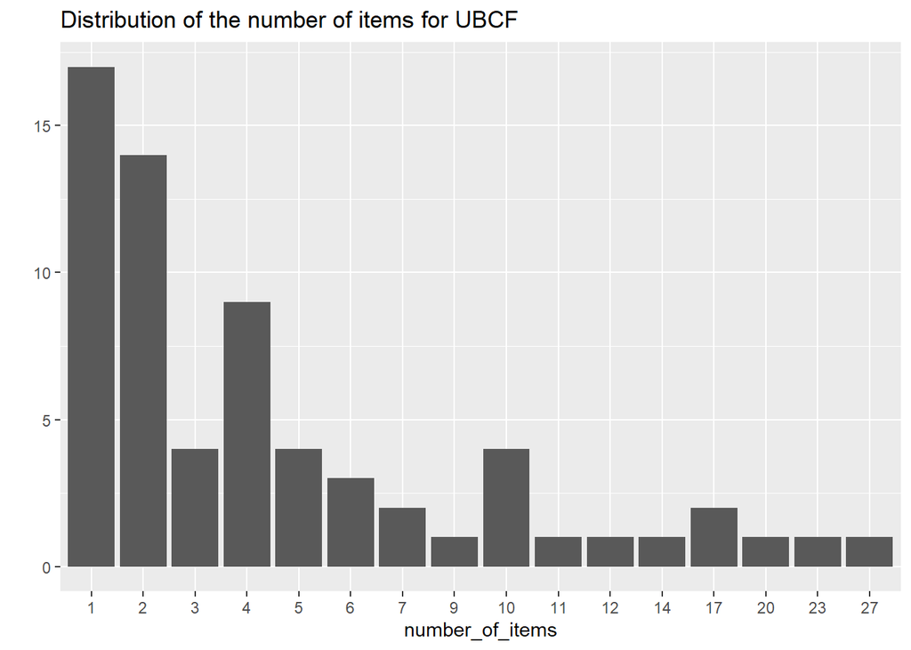

```r
number_of_items <- factor(table(UBCF_recc_matrix))
chart_title <- "Distribution of the number of items for UBCF"
qplot(number_of_items) + ggtitle(chart_title)
```

## 6.2 Method Two - using the K-FOld sets

For Method two, I built the UBCF model using the K-fold split data. The custom function, build_UBCF_Model, creates the UBCF recommender model.

```r
build_UBCF_Model <- function(data, model_to_evaluate, model_parameters ){

                return( Recommender(data = data, method = model_to_evaluate, parameter = model_parameters))
  }
```

The data used is from the eval sets. We see that the UBCF_eval_recommender is part of the Recommender package.

```r
data <- getData(eval_sets, "train")
model_to_evaluate <- "UBCF"
model_parameters <- NULL

UBCF_eval_recommender <- build_UBCF_Model(data,model_to_evaluate,model_parameters)
```

```r
class(UBCF_eval_recommender)
```

```
## [1] "Recommender"
## attr(,"package")
## [1] "recommenderlab"
```

```r
UBCF_model_details <- getModel(UBCF_eval_recommender)
```

We see that the data is normalize.

```r
UBCF_model_details$normalize
```

```
## [1] "center"
```

```r
items_to_recommend <- 5
```

```r
UBCF_eval_prediction <- predict(object = UBCF_eval_recommender, newdata = getData(eval_sets, "known"), n = items_to_recommend, type = "ratings")
```

## 6.3 RMSE

I calculated the RMSE, MSE, and MAE both by user and by the entirety of the model.

```r
UBCF_eval_accuracy_users <- calcPredictionAccuracy(x = UBCF_eval_prediction, data = getData(eval_sets, "unknown"), byUser =TRUE)
UBCF_eval_accuracy <- calcPredictionAccuracy(x = UBCF_eval_prediction, data = getData(eval_sets, "unknown"), byUser =FALSE)
```

```r
head(UBCF_eval_accuracy_users)
```

```
##          RMSE       MSE       MAE
## 7   0.9259111 0.8573114 0.7428040
## 11  0.8982434 0.8068411 0.7330236
## 85  0.8311870 0.6908718 0.6980006
## 95  0.9936766 0.9873931 0.7961966
## 125 1.6367242 2.6788661 1.1488154
## 141 1.1074558 1.2264583 0.7645077
```

```r
UBCF_eval_accuracy
```

```
##      RMSE       MSE       MAE
## 0.9906267 0.9813413 0.7753522
```

# 7 Precision and Recall

To further evaluate the UBCF model, I used the evaluate function which tests and validates using the 8 k-fold sets and recommendations starting at 10 to to 100 movies.

```r
results <- evaluate(x = eval_sets, method = model_to_evaluate, n =seq(10, 100, 10))
```

```
## UBCF run fold/sample [model time/prediction time]
##   1  [0sec/0.08sec]
##   2  [0sec/0.03sec]
##   3  [0sec/0.03sec]
##   4  [0sec/0.05sec]
##   5  [0sec/0.03sec]
##   6  [0sec/0.03sec]
##   7  [0sec/0.03sec]
##   8  [0sec/0.03sec]
```

```r
getConfusionMatrix(results)[[1]]
```

```
##        TP    FP    FN    TN precision     recall        TPR       FPR
## 10   4.56  5.44 38.80 57.20 0.4560000 0.09774008 0.09774008 0.0850141
## 20   8.82 11.18 34.54 51.46 0.4410000 0.19333183 0.19333183 0.1750696
## 30  13.50 16.50 29.86 46.14 0.4500000 0.30022102 0.30022102 0.2583568
## 40  17.86 22.14 25.50 40.50 0.4465000 0.39704363 0.39704363 0.3461648
## 50  22.06 27.94 21.30 34.70 0.4412000 0.49225501 0.49225501 0.4365857
## 60  26.42 33.58 16.94 29.06 0.4403333 0.59318206 0.59318206 0.5264497
## 70  30.64 39.36 12.72 23.28 0.4377143 0.68613332 0.68613332 0.6169256
## 80  34.54 45.46  8.82 17.18 0.4317500 0.78187313 0.78187313 0.7167004
## 90  38.40 51.60  4.96 11.04 0.4266667 0.88092366 0.88092366 0.8169180
## 100 41.76 58.24  1.60  4.40 0.4176000 0.96194529 0.96194529 0.9260601
```

```r
columns_to_sum <- c("TP", "FP", "FN", "TN")
indices_summed <- Reduce("+", getConfusionMatrix(results))[, columns_to_sum]
indices_summed
```

```
##         TP     FP     FN     TN
## 10   38.54  41.46 322.32 445.68
## 20   76.04  83.96 284.82 403.18
## 30  112.80 127.20 248.06 359.94
## 40  148.78 171.22 212.08 315.92
## 50  185.44 214.56 175.42 272.58
## 60  221.76 258.24 139.10 228.90
## 70  256.96 303.04 103.90 184.10
## 80  289.00 351.00  71.86 136.14
## 90  320.40 399.60  40.46  87.54
## 100 346.60 453.40  14.26  33.74
```

## 7.1 The ROC curve

Shows the relationship between the True Positive Rate (TPR) and the False Positive Rate (FPR). The TPR is the number of TP divided by the sum of True Positives(TP) + False Negatives(FN). This rate shows whether the recommdended item was rated by the user. The FPR is the number of FP divided by the sum of False Positives(TP) + True Negatives(FN). FPR measures recommendations that were not rated by the user.

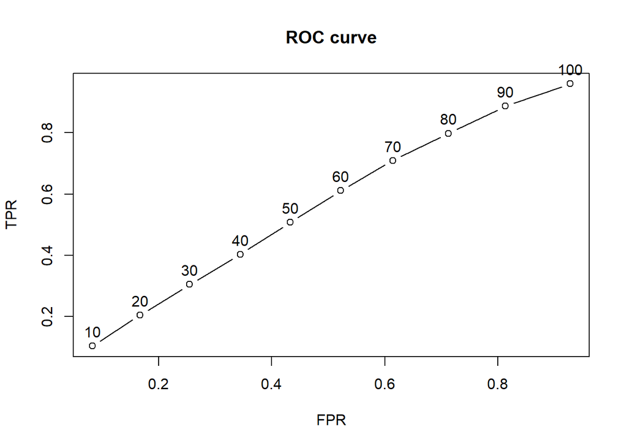

```r
plot(results, annotate = TRUE, main = "ROC curve")
```

We can see clearly in the chart below that as the number of recommended movies increases, Precision falls but Recall increases.

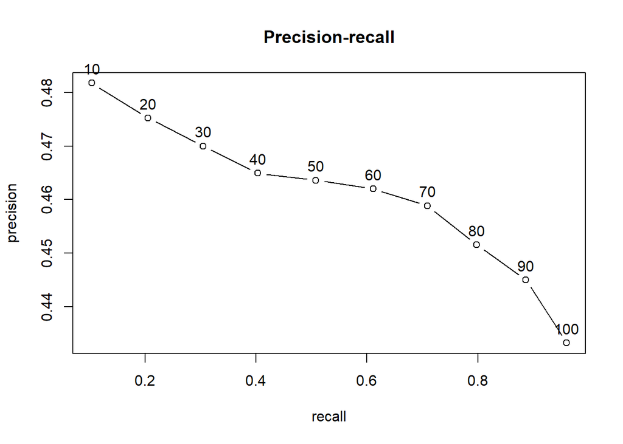

```r
plot(results, "prec/rec", annotate = TRUE, main = "Precision-recall")
```